# Multi-Level Modeling of Enrollment

# Setup

```r
library(tidyverse)
library(lme4)
```

```r
full_dat3 <- read_csv("../Data/full_dat3.csv")
str(full_dat3)
```

```
spc_tbl_ [7,762 × 16] (S3: spec_tbl_df/tbl_df/tbl/data.frame)
 $ unit_id                 : num [1:7762] 222178 222178 222178 222178 222178 ...
 $ institution_name        : chr [1:7762] "Abilene Christian University" "Abilene Christian University" "Abilene Christian University" "Abilene Christian University" ...
 $ year                    : num [1:7762] 2023 2022 2021 2020 2019 ...
 $ pct_pell                : num [1:7762] 22 24 26 26 26 60 73 34 37 37 ...
 $ overall_enrollment      : num [1:7762] 3188 3211 3138 3494 3525 ...
 $ pct_race_minority       : num [1:7762] 37 36 37 39 37 55 62 22 21 20 ...
 $ avg_net_price_w_aid     : num [1:7762] 28311 28978 29734 28725 27883 ...
 $ applicants              : num [1:7762] 10510 11226 8208 10534 11379 ...
 $ admissions_rate         : num [1:7762] 0.639 0.658 0.701 0.634 0.615 ...
 $ stabbr                  : chr [1:7762] "TX" "TX" "TX" "TX" ...
 $ locale_rural            : chr [1:7762] "City/Suburb" "City/Suburb" "City/Suburb" "City/Suburb" ...
 $ hs_grad_state           : num [1:7762] 385604 375741 377064 372402 364979 ...
 $ pct_bachelors_2018_state: num [1:7762] 30.3 30.3 30.3 30.3 30.3 30.3 30.3 31.9 31.9 31.9 ...
 $ carnegie                : chr [1:7762] "R0" "R0" "R0" "R0" ...
 $ sector                  : chr [1:7762] "private" "private" "private" "private" ...
 $ first_time_enrollment   : num [1:7762] 862 894 833 859 932 ...
 - attr(*, "spec")=
  .. cols(
  ..   unit_id = col_double(),
  ..   institution_name = col_character(),
  ..   year = col_double(),
  ..   pct_pell = col_double(),
  ..   overall_enrollment = col_double(),
  ..   pct_race_minority = col_double(),
  ..   avg_net_price_w_aid = col_double(),
  ..   applicants = col_double(),
  ..   admissions_rate = col_double(),
  ..   stabbr = col_character(),
  ..   locale_rural = col_character(),
  ..   hs_grad_state = col_double(),
  ..   pct_bachelors_2018_state = col_double(),
  ..   carnegie = col_character(),
  ..   sector = col_character(),
  ..   first_time_enrollment = col_double()
  .. )
 - attr(*, "problems")=<externalptr>
```

```r
public_dat3 <- full_dat3 %>% filter(sector == "public")
private_dat3 <- full_dat3 %>% filter(sector == "private")
```

```r
public_dat3 %>%
  group_by(unit_id) %>%
  summarise(N_year = length(unique(year))) %>%
  ungroup() %>%
  count(N_year)
```

| N_year | n |
| --- | --- |
| 1 | 2 |
| 2 | 25 |
| 3 | 3 |
| 4 | 6 |
| 5 | 494 |

```r
private_dat3 %>%
  group_by(unit_id) %>%
  summarise(N_year = length(unique(year))) %>%
  ungroup() %>%
  count(N_year)
```

| N_year | n |
| --- | --- |
| 1 | 13 |
| 2 | 22 |
| 3 | 13 |
| 4 | 29 |
| 5 | 999 |

36 out of 530 public institutions do not have 5 years of IPEDS data 77 out of 1076 private institutions do not have 5 years of IPEDS data

```r
public_dat3 %>%
  group_by(unit_id) %>%
  summarise(Min_Enrl = min(overall_enrollment), Max_Enrl = max(overall_enrollment)) %>%
  ungroup() %>%
  count(Min_Enrl < 1000, Max_Enrl > 1000)
```

| Min_Enrl < 1000 | Max_Enrl > 1000 | n |
| --- | --- | --- |
| FALSE | TRUE | 502 |
| TRUE | FALSE | 26 |
| TRUE | TRUE | 2 |

```r
  # filter(Min_Enrl < 1000, Max_Enrl > 1000)
private_dat3 %>%
  group_by(unit_id) %>%
  summarise(Min_Enrl = min(overall_enrollment), Max_Enrl = max(overall_enrollment)) %>%
  ungroup() %>%
  count(Min_Enrl < 1000, Max_Enrl > 1000)
```

| Min_Enrl < 1000 | Max_Enrl > 1000 | n |
| --- | --- | --- |
| FALSE | TRUE | 613 |
| TRUE | FALSE | 373 |
| TRUE | TRUE | 90 |

```r
  # filter(Min_Enrl < 1000, Max_Enrl > 1000)
```

2 out of 530 public institutions cross the 1000 overall enrollment threshold in this period. 90 out of 1076 private institutions cross the 1000 overall enrollment threshold in this period.

```r
public_dat3 %>%
  group_by(unit_id) %>%
  filter(year == min(year)) %>%
  ungroup() %>%
  filter(overall_enrollment >= 1000) %>%
  distinct(unit_id) %>%
  left_join(
    y = public_dat3,
    by = "unit_id"
  )
```

| unit_id | institution_name | year | pct_pell | overall_enrollment | pct_race_minority | avg_net_price_w_aid | applicants | admissions_rate | stabbr | locale_rural | hs_grad_state | pct_bachelors_2018_state | carnegie | sector | first_time_enrollment |
| --- | --- | --- | --- | --- | --- | --- | --- | --- | --- | --- | --- | --- | --- | --- | --- |
| 138558 | Abraham Baldwin Agricultural College | 2023 | 34 | 3768 | 22 | 6923 | 2618 | 0.7715814 | GA | Town/Rural | 126146 | 31.9 | Baccalaureate | public | 1006 |
| 138558 | Abraham Baldwin Agricultural College | 2022 | 37 | 3647 | 21 | 7260 | 2349 | 0.6696467 | GA | Town/Rural | 122695 | 31.9 | Baccalaureate | public | 856 |
| 138558 | Abraham Baldwin Agricultural College | 2021 | 37 | 3814 | 20 | 7744 | 2200 | 0.7536364 | GA | Town/Rural | 124712 | 31.9 | Baccalaureate | public | 865 |
| 138558 | Abraham Baldwin Agricultural College | 2020 | 39 | 3990 | 22 | 8106 | 2403 | 0.7598835 | GA | Town/Rural | 126126 | 31.9 | Baccalaureate | public | 934 |
| 138558 | Abraham Baldwin Agricultural College | 2019 | 40 | 3927 | 21 | 6823 | 2009 | 0.7341961 | GA | Town/Rural | 121897 | 31.9 | Baccalaureate | public | 919 |
| 126182 | Adams State University | 2022 | 36 | 1588 | 63 | 13224 | 1580 | 0.9917722 | CO | Town/Rural | 64869 | 41.7 | M | public | 306 |
| 126182 | Adams State University | 2021 | 37 | 1835 | 62 | 14492 | 1717 | 0.9982528 | CO | Town/Rural | 63204 | 41.7 | M | public | 318 |
| 126182 | Adams State University | 2020 | 41 | 1902 | 57 | 13193 | 1690 | 0.9988166 | CO | Town/Rural | 61237 | 41.7 | M | public | 348 |
| 126182 | Adams State University | 2019 | 44 | 1955 | 61 | 13383 | 1765 | 0.9909348 | CO | Town/Rural | 60962 | 41.7 | M | public | 399 |
| 100654 | Alabama A & M University | 2023 | 64 | 5845 | 98 | 14064 | 15628 | 0.6622089 | AL | City/Suburb | 52181 | 25.5 | M | public | 1990 |

[output cut: 990 more lines]

```r
private_dat3 %>%
  group_by (unit_id) %>%
  filter(year == min(year)) %>%
  ungroup() %>%
  filter(overall_enrollment >= 1000) %>%
  distinct(unit_id) %>%
  left_join(
    y = private_dat3,
    by = "unit_id"
  )
```

| unit_id | institution_name | year | pct_pell | overall_enrollment | pct_race_minority | avg_net_price_w_aid | applicants | admissions_rate | stabbr | locale_rural | hs_grad_state | pct_bachelors_2018_state | carnegie | sector | first_time_enrollment |
| --- | --- | --- | --- | --- | --- | --- | --- | --- | --- | --- | --- | --- | --- | --- | --- |
| 222178 | Abilene Christian University | 2023 | 22 | 3188 | 37 | 28311 | 10510 | 0.63882017 | TX | City/Suburb | 385604 | 30.3 | R0 | private | 862 |
| 222178 | Abilene Christian University | 2022 | 24 | 3211 | 36 | 28978 | 11226 | 0.65793693 | TX | City/Suburb | 375741 | 30.3 | R0 | private | 894 |
| 222178 | Abilene Christian University | 2021 | 26 | 3138 | 37 | 29734 | 8208 | 0.70114522 | TX | City/Suburb | 377064 | 30.3 | R0 | private | 833 |
| 222178 | Abilene Christian University | 2020 | 26 | 3494 | 39 | 28725 | 10534 | 0.63404215 | TX | City/Suburb | 372402 | 30.3 | R0 | private | 859 |
| 222178 | Abilene Christian University | 2019 | 26 | 3525 | 37 | 27883 | 11379 | 0.61481677 | TX | City/Suburb | 364979 | 30.3 | R0 | private | 932 |
| 188429 | Adelphi University | 2023 | 29 | 5124 | 57 | 28671 | 17111 | 0.77511542 | NY | City/Suburb | 211853 | 37.2 | R0 | private | 1377 |
| 188429 | Adelphi University | 2022 | 29 | 5055 | 56 | 26953 | 17301 | 0.72776140 | NY | City/Suburb | 213993 | 37.2 | R0 | private | 1146 |
| 188429 | Adelphi University | 2021 | 28 | 5251 | 55 | 28261 | 16084 | 0.77462074 | NY | City/Suburb | 217586 | 37.2 | R0 | private | 1330 |
| 188429 | Adelphi University | 2020 | 27 | 5124 | 52 | 29821 | 15329 | 0.74610216 | NY | City/Suburb | 209688 | 37.2 | R0 | private | 996 |
| 188429 | Adelphi University | 2019 | 32 | 5360 | 51 | 28130 | 13919 | 0.74301315 | NY | City/Suburb | 212104 | 37.2 | R0 | private | 1132 |

[output cut: 990 more lines]

```r
private_dat3 %>%
  group_by (unit_id) %>%
  filter(year == min(year)) %>%
  ungroup() %>%
  filter(overall_enrollment < 1000) %>%
  mutate(
    Enrl_Level = case_when(
      overall_enrollment >= 800 ~ "800+",
      overall_enrollment >= 600 ~ "600-800",
      overall_enrollment >= 400 ~ "400-600",
      overall_enrollment >= 200 ~ "200-400",
      overall_enrollment > 0 ~ "1-200"
    )
  ) %>%
  count(Enrl_Level)
```

| Enrl_Level | n |
| --- | --- |
| 1-200 | 123 |
| 200-400 | 58 |
| 400-600 | 60 |
| 600-800 | 79 |
| 800+ | 77 |

```r
NA
```

504 of 530 public institutions enrolled at least 1000 students in their first reporting year in this period. 679 of 1076 private institutions enrolled at least 1000 students in their first reporting year in this period.

```r
public_dat3 %>%
  distinct(unit_id, carnegie) %>%
  count(carnegie)
```

| carnegie | n |
| --- | --- |
| Baccalaureate | 61 |
| M | 213 |
| Not Carnegie | 26 |
| R0 | 29 |
| R1 | 106 |
| R2 | 89 |
| Special or Tribal | 6 |

```r
private_dat3 %>%
  distinct(unit_id, carnegie) %>%
  count(carnegie)
```

| carnegie | n |
| --- | --- |
| Baccalaureate | 350 |
| M | 324 |
| Not Carnegie | 15 |
| R0 | 126 |
| R1 | 39 |
| R2 | 37 |
| Special or Tribal | 175 |
| Two-Year | 10 |

```r
table(full_dat3$carnegie)
```

```
    Baccalaureate                 M      Not Carnegie                R0                R1                R2 Special or Tribal
             2009              2637               121               767               723               624               835
         Two-Year
               46
```

```r
table(private_dat3_x5$carnegie)
```

[output not shown]

26 out of 530 public institutions were not in the Carnegie universe. 15 out of 1076 private institutions were not in the Carnegie universe.

```r
public_dat3_x <- public_dat3 %>%
  # In the Carnegie universe
  filter(carnegie != "Not Carnegie") %>%
  # At least 1000 overall enrollment in first reporting year
  group_by(unit_id) %>%
  filter(year == min(year)) %>%
  ungroup() %>%
  filter(overall_enrollment >= 1000) %>%
  distinct(unit_id) %>%
  left_join(
    y = public_dat3,
    by = "unit_id"
  ) %>%
  # Has all 5 years of data
  group_by(unit_id) %>%
  summarise(N_year = length(unique(year))) %>%
  ungroup() %>%
  left_join(
    y = public_dat3,
    by = "unit_id"
  ) %>%
  mutate(
    year_0 = year - min(year),
    # Log transforms: first-time enrollment; HS grads by state; applicants; average net price with aid
    log_fyr = log(first_time_enrollment),
    log_hs = log(hs_grad_state),
    log_apps = log(applicants),
    log_price = log(avg_net_price_w_aid),
    sy_fyr = scale(log_fyr),
    x_year = year_0,
    sx_hs = scale(log_hs), # log this
    sx_bach = scale(pct_bachelors_2018_state),
    x_rural = factor(locale_rural),
    sx_pell = scale(pct_pell),
    sx_race_minority = scale(pct_race_minority),
    sx_price = scale(log_price), # don't log this
    sx_apps = scale(log_apps), # log this
    sx_admit_rate = scale(admissions_rate)
  )

public_dat3_x5 <- filter(public_dat3_x, N_year == 5)

private_dat3_x <- private_dat3 %>%
  # In the Carnegie universe
  filter(carnegie != "Not Carnegie") %>%
  # At least 1000 overall enrollment in first reporting year
  group_by(unit_id) %>%
  filter(year == min(year)) %>%
  ungroup() %>%
  filter(overall_enrollment >= 1000) %>%
  distinct(unit_id) %>%
  left_join(
    y = private_dat3,
    by = "unit_id"
  ) %>%
  # Has all 5 years of data
  group_by(unit_id) %>%
  summarise(N_year = length(unique(year))) %>%
  ungroup() %>%
  left_join(
    y = private_dat3,
    by = "unit_id"
  ) %>%
  mutate(
    year_0 = year - min(year),
    # Log transforms: first-time enrollment; HS grads by state; applicants; average net price with aid
    log_fyr = log(first_time_enrollment),
    log_hs = log(hs_grad_state),
    log_apps = log(applicants),
    log_price = log(avg_net_price_w_aid),
    sy_fyr = scale(log_fyr),
    x_year = year_0,
    sx_hs = scale(log_hs),
    sx_bach = scale(pct_bachelors_2018_state),
    x_rural = factor(locale_rural),
    sx_pell = scale(pct_pell),
    sx_race_minority = scale(pct_race_minority),
    sx_price = scale(log_price),
    sx_apps = scale(log_apps),
    sx_admit_rate = scale(admissions_rate)
  )

private_dat3_x5 <- filter(private_dat3_x, N_year == 5)
```

```r
distinct(public_dat3_x5, unit_id) ; distinct(private_dat3_x5, unit_id)
```

| unit_id |
| --- |
| 100654 |
| 100663 |
| 100706 |
| 100724 |
| 100751 |
| 100830 |
| 100858 |
| 101480 |
| 101587 |
| 101709 |

[output cut: 469 more lines]

| unit_id |
| --- |
| 100937 |
| 101189 |
| 101435 |
| 101693 |
| 101912 |
| 102049 |
| 102234 |
| 102377 |
| 104586 |
| 107044 |

[output cut: 652 more lines]

```r
distinct(public_dat3_x, unit_id) ; distinct(private_dat3_x, unit_id)
```

| unit_id |
| --- |
| 100654 |
| 100663 |
| 100706 |
| 100724 |
| 100751 |
| 100830 |
| 100858 |
| 101480 |
| 101587 |
| 101709 |

[output cut: 483 more lines]

| unit_id |
| --- |
| 100937 |
| 101189 |
| 101435 |
| 101693 |
| 101912 |
| 102049 |
| 102234 |
| 102377 |
| 104586 |
| 107044 |

[output cut: 669 more lines]

```r
NA
```

479 out of 530 public institutions meet the criteria … 662 out of 1076 private institutions meet the criteria …

# Model 1: Basic Growth Model (Null Model)

```r
formula_1 <- formula(
  first_time_enrollment ~
    1
    + x_year
    # + (1 + x_year | carnegie)
    + (1 + x_year | unit_id)
)
```

## Model Estimation: Public Institutions

```r
m_public_1 <- lme4::lmer(
  formula = formula_1,
  data = public_dat3_x5
)
summary(m_public_1)
```

```
Linear mixed model fit by REML ['lmerMod']
Formula: first_time_enrollment ~ 1 + x_year + (1 + x_year | unit_id)
   Data: public_dat3_x5

REML criterion at convergence: 35828.1

Scaled residuals:
    Min      1Q  Median      3Q     Max
-7.3975 -0.3351 -0.0187  0.3006  5.1821

Random effects:
 Groups   Name        Variance Std.Dev. Corr
 unit_id  (Intercept) 3621566  1903.0
          x_year        12842   113.3   0.69
 Residual               46149   214.8
Number of obs: 2395, groups:  unit_id, 479

Fixed effects:
            Estimate Std. Error t value
(Intercept) 2120.932     87.284  24.299
x_year        36.911      6.037   6.114

Correlation of Fixed Effects:
       (Intr)
x_year 0.552
```

```r
coef(m_public_1)
```

```
$unit_id
       (Intercept)       x_year
100654   1572.2142   40.6262452
100663   2256.2772   -6.9962836
100706   1368.6023  -45.3835740
100724    988.8692  -15.3560812
100751   6703.2716  364.4368891
100830    638.3217  -52.1640343
100858   4814.2625  218.5309817
101480   1525.9886   77.5862203
101587    337.7728  -15.6384783
101709    524.2561   -9.3559105
101879   1017.3173   15.3098622
102094   1617.9821   43.1007311
102368   1702.1941    2.1435526
```

[output cut: 469 more lines]

```r
# fitted(m_public_1)
# resid(m_public_1)
```

## Model Estimation: Private Institutions

```r
m_private_1 <- lme4::lmer(
  formula = formula_1,
  data = private_dat3_x5
)
summary(m_private_1)
```

```
Linear mixed model fit by REML ['lmerMod']
Formula: first_time_enrollment ~ 1 + x_year + (1 + x_year | unit_id)
   Data: private_dat3_x5

REML criterion at convergence: 44446.4

Scaled residuals:
     Min       1Q   Median       3Q      Max
-14.9834  -0.2666  -0.0182   0.2374  13.0539

Random effects:
 Groups   Name        Variance Std.Dev. Corr
 unit_id  (Intercept) 550596   742.02
          x_year        2544    50.44   0.64
 Residual              10932   104.55
Number of obs: 3310, groups:  unit_id, 662

Fixed effects:
            Estimate Std. Error t value
(Intercept)  674.158     29.011  23.238
x_year         4.905      2.344   2.092

Correlation of Fixed Effects:
       (Intr)
x_year 0.486
```

```r
coef(m_private_1)
```

```
$unit_id
       (Intercept)       x_year
100937   299.43264 -27.07099534
101189   277.53240 -12.89402434
101435   258.40551   1.28703079
101693   273.58866  -2.78596137
101912   317.43293  -2.34212454
102049   914.11215  27.45304275
102234   275.75197 -16.71999586
102377   516.90721  38.55268967
104586   740.80677  13.13418328
107044   766.95439  13.58643846
107080   318.36046  -3.54752728
107141   330.49749   1.50429540
107512   440.53176   3.37496708
```

[output cut: 491 more lines]

```r
# fitted(m_private_1)
# resid(m_private_1)
```

## Results Visualization: Overall FYR recruitment trends

```r
public_fyr_normalized <- public_dat3_x5 %>%
  filter(x_year==0) %>%
  select(unit_id, first_time_enrollment, overall_enrollment) %>%
  rename(baseline_enrollment = first_time_enrollment, baseline_overall=overall_enrollment) %>%
  left_join(
    y = public_dat3_x5 %>% select(unit_id, institution_name, carnegie, year, x_year, first_time_enrollment),
    by = "unit_id"
  ) %>%
  mutate(
    normalized_enrollment = first_time_enrollment / baseline_enrollment,
    size_category = case_when(
      baseline_overall >= 1000 & baseline_overall < 5000 ~ "1k-5k",
      baseline_overall >= 5000 & baseline_overall < 10000 ~ "5k-10k",
      baseline_overall >= 10000 & baseline_overall < 20000 ~ "10k-20k",
      baseline_overall >= 20000 ~ "20k+"
    ) %>% factor(levels = c("1k-5k","5k-10k","10k-20k","20k+")),
    carnegie_category = factor(
      carnegie,
      levels = c("R1", "R2", "R0", "M", "Baccalaureate", "Special or Tribal"),
      labels = c("R1", "R2", "D/PU", "M", "B", "SF&TCU")
    )
  ) %>%
  left_join(
    y = tibble(
      unit_id = rownames(coef(m_public_1)$unit_id) %>% as.numeric(),
      time_slope = coef(m_public_1)$unit_id[,"x_year"],
      enrl_intcpt = coef(m_public_1)$unit_id[,"(Intercept)"],
      growth_pct = time_slope / enrl_intcpt,
      growth_bucket = case_when(
        growth_pct < -0.05 ~ "Linear Decline more than 5% per year",
        growth_pct < -0.01 ~ "Linear Decline 1 to 5% per year",
        growth_pct <= 0.01 ~ "Linear Change less than 1% per year",
        growth_pct <= 0.05 ~ "Linear Growth 1 to 5% per year",
        growth_pct > 0.05 ~ "Linear Growth more than 5% per year"
      ) %>% factor(levels = c("Linear Decline more than 5% per year","Linear Decline 1 to 5% per year","Linear Change less than 1% per year","Linear Growth 1 to 5% per year","Linear Growth more than 5% per year"))
    ) ,
    by = "unit_id"
  )

public_fyr_slope_avg <- public_fyr_normalized %>%
  group_by(size_category, carnegie_category) %>%
  summarise(Avg_Slope = mean(growth_pct))
```

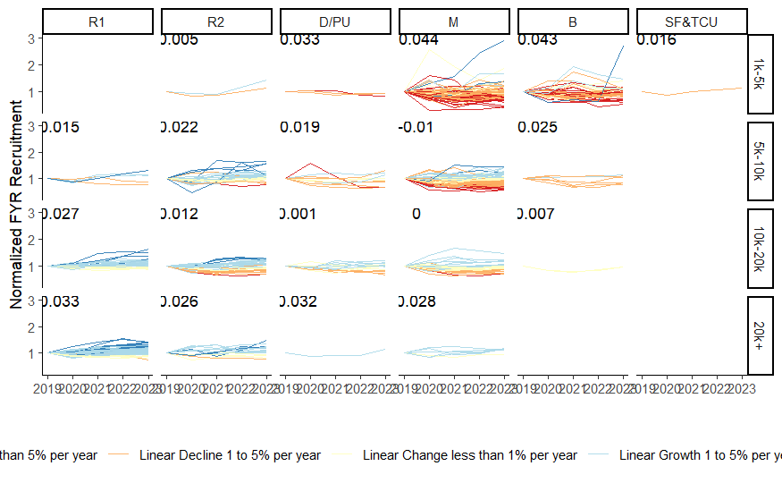

```r
# public_fyr_normalized %>%
#   ggplot(aes(x=x_year, y=normalized_enrollment, group=unit_id, color=growth_bucket)) +
#   geom_line(alpha = 0.9) +
#   scale_color_brewer(type="div", palette = "RdYlBu") +
#   facet_wrap(~size_category) +
#   theme_classic()
#
# public_fyr_normalized %>%
#   ggplot(aes(x=x_year, y=normalized_enrollment, group=unit_id, color=growth_bucket)) +
#   geom_line(alpha = 0.9) +
#   scale_color_brewer(type="div", palette = "RdYlBu") +
#   facet_wrap(~carnegie_category) +
#   theme_classic()

public_fyr_normalized %>%
  ggplot(aes(x=x_year, y=normalized_enrollment)) +
  geom_line(mapping=aes(group=unit_id, color=growth_bucket), alpha = 0.9) +
  scale_color_brewer(type="div", palette = "RdYlBu") +
  geom_text(data=public_fyr_slope_avg, mapping=aes(x=0.5,y=3,label=round(Avg_Slope, 3))) +
  scale_y_continuous(name = "Normalized FYR Recruitment") +
  scale_x_continuous(name = "", labels = c(2019, 2020, 2021, 2022, 2023)) +
  facet_grid(size_category~carnegie_category) +
  # geom_abline(data=public_fyr_slope_avg, mapping=aes(slope=Avg_Slope, intercept=1), linewidth=1, linetype = 1) +
  theme_classic() +
  theme(legend.position = "bottom")
ggsave("../Results/normalized_fyr_public.png")
```

```r
private_fyr_normalized <- private_dat3_x5 %>%
  filter(x_year==0) %>%
  select(unit_id, first_time_enrollment, overall_enrollment) %>%
  rename(baseline_enrollment = first_time_enrollment, baseline_overall=overall_enrollment) %>%
  left_join(
    y = private_dat3_x5 %>% select(unit_id, institution_name, carnegie, year, x_year, first_time_enrollment),
    by = "unit_id"
  ) %>%
  mutate(
    normalized_enrollment = first_time_enrollment / baseline_enrollment,
    size_category = case_when(
      baseline_overall >= 1000 & baseline_overall < 5000 ~ "1k-5k",
      baseline_overall >= 5000 & baseline_overall < 10000 ~ "5k-10k",
      baseline_overall >= 10000 & baseline_overall < 20000 ~ "10k-20k",
      baseline_overall >= 20000 ~ "20k+"
    ) %>% factor(levels = c("1k-5k","5k-10k","10k-20k","20k+")),
    carnegie_category = factor(
      carnegie,
      levels = c("R1", "R2", "R0", "M", "Baccalaureate", "Special or Tribal"),
      labels = c("R1", "R2", "D/PU", "M", "B", "SF&TCU")
    )
  ) %>%
  left_join(
    y = tibble(
      unit_id = rownames(coef(m_private_1)$unit_id) %>% as.numeric(),
      time_slope = coef(m_private_1)$unit_id[,"x_year"],
      enrl_intcpt = coef(m_private_1)$unit_id[,"(Intercept)"],
      growth_pct = time_slope / enrl_intcpt,
      growth_bucket = case_when(
        growth_pct < -0.05 ~ "Linear Decline more than 5% per year",
        growth_pct < -0.01 ~ "Linear Decline 1 to 5% per year",
        growth_pct <= 0.01 ~ "Linear Change less than 1% per year",
        growth_pct <= 0.05 ~ "Linear Growth 1 to 5% per year",
        growth_pct > 0.05 ~ "Linear Growth more than 5% per year"
      ) %>% factor(levels = c("Linear Decline more than 5% per year","Linear Decline 1 to 5% per year","Linear Change less than 1% per year","Linear Growth 1 to 5% per year","Linear Growth more than 5% per year"))
    ) ,
    by = "unit_id"
  )

private_fyr_slope_avg <- private_fyr_normalized %>%
  group_by(size_category, carnegie_category) %>%
  summarise(Avg_Slope = mean(growth_pct))
```

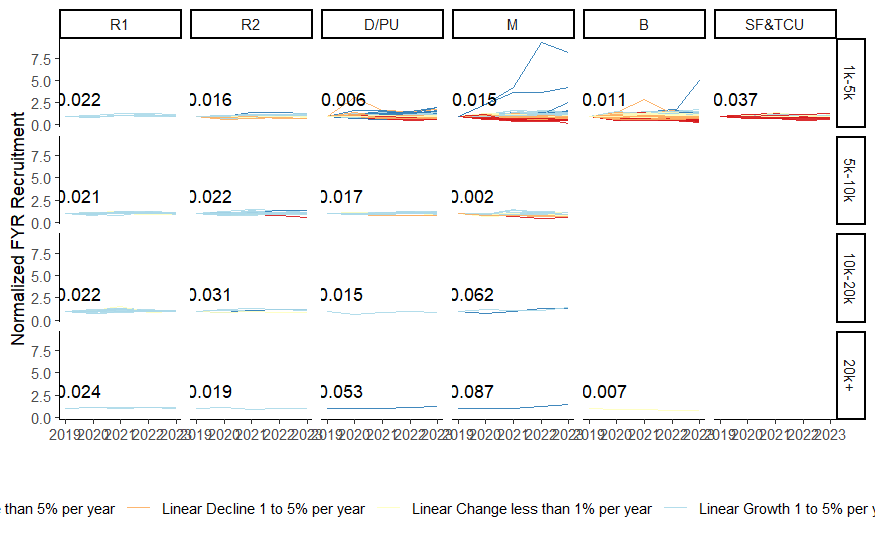

```r
private_fyr_normalized %>%
  ggplot(aes(x=x_year, y=normalized_enrollment)) +
  geom_line(mapping=aes(group=unit_id, color=growth_bucket), alpha = 0.9) +
  scale_color_brewer(type="div", palette = "RdYlBu") +
  geom_text(data=private_fyr_slope_avg, mapping=aes(x=0.5,y=3,label=round(Avg_Slope, 3))) +
  scale_y_continuous(name = "Normalized FYR Recruitment") +
  scale_x_continuous(name = "", labels = c(2019, 2020, 2021, 2022, 2023)) +
  facet_grid(size_category~carnegie_category) +
  # geom_abline(data=private_fyr_slope_avg, mapping=aes(slope=Avg_Slope, intercept=1), linewidth=1, linetype = 1) +
  theme_classic() +
  theme(legend.position = "bottom")
ggsave("../Results/normalized_fyr_private.png")
```

```r
public_fyr_normalized %>%
  distinct(unit_id, growth_pct, growth_bucket) %>%
  count(growth_bucket) %>%
  mutate(pct = round(n/sum(n), 2))
```

| growth_bucket | n | pct |
| --- | --- | --- |
| Linear Decline more than 5% per year | 61 | 0.13 |
| Linear Decline 1 to 5% per year | 134 | 0.28 |
| Linear Change less than 1% per year | 90 | 0.19 |
| Linear Growth 1 to 5% per year | 159 | 0.33 |
| Linear Growth more than 5% per year | 35 | 0.07 |

```r
private_fyr_normalized %>%
  distinct(unit_id, growth_pct, growth_bucket) %>%
  count(growth_bucket) %>%
  mutate(pct = round(n/sum(n), 2))
```

| growth_bucket | n | pct |
| --- | --- | --- |
| Linear Decline more than 5% per year | 73 | 0.11 |
| Linear Decline 1 to 5% per year | 224 | 0.34 |
| Linear Change less than 1% per year | 149 | 0.23 |
| Linear Growth 1 to 5% per year | 193 | 0.29 |
| Linear Growth more than 5% per year | 23 | 0.03 |

```r
public_fyr_normalized %>%
  distinct(unit_id, growth_pct, growth_bucket, carnegie, size_category) %>%
  group_by(carnegie, size_category) %>%
  summarise(
    tot_decline = sum(growth_bucket %in% c("Linear Decline 1 to 5% per year","Linear Decline more than 5% per year")),
    tot_inst = length(unique(unit_id)),
    decline_frac = paste0(tot_decline,"/",tot_inst, " (", 100*round(tot_decline/tot_inst,2), "%)")
  )
```

| carnegie | size_category | tot_decline | tot_inst | decline_frac |
| --- | --- | --- | --- | --- |
| Baccalaureate | 1k-5k | 34 | 44 | 34/44 (77%) |
| Baccalaureate | 5k-10k | 5 | 6 | 5/6 (83%) |
| Baccalaureate | 10k-20k | 0 | 2 | 0/2 (0%) |
| M | 1k-5k | 69 | 82 | 69/82 (84%) |
| M | 5k-10k | 44 | 88 | 44/88 (50%) |
| M | 10k-20k | 10 | 30 | 10/30 (33%) |
| M | 20k+ | 0 | 6 | 0/6 (0%) |
| R0 | 1k-5k | 3 | 3 | 3/3 (100%) |
| R0 | 5k-10k | 6 | 10 | 6/10 (60%) |
| R0 | 10k-20k | 4 | 14 | 4/14 (29%) |

[output cut: 9 more lines]

```r
private_fyr_normalized %>%
  distinct(unit_id, growth_pct, growth_bucket, carnegie, size_category) %>%
  group_by(carnegie, size_category) %>%
  summarise(
    tot_decline = sum(growth_bucket %in% c("Linear Decline 1 to 5% per year","Linear Decline more than 5% per year")),
    tot_inst = length(unique(unit_id)),
    decline_frac = paste0(tot_decline,"/",tot_inst, " (", 100*round(tot_decline/tot_inst,2), "%)")
  )
```

| carnegie | size_category | tot_decline | tot_inst | decline_frac |
| --- | --- | --- | --- | --- |
| Baccalaureate | 1k-5k | 98 | 199 | 98/199 (49%) |
| Baccalaureate | 20k+ | 0 | 1 | 0/1 (0%) |
| M | 1k-5k | 129 | 236 | 129/236 (55%) |
| M | 5k-10k | 3 | 13 | 3/13 (23%) |
| M | 10k-20k | 0 | 2 | 0/2 (0%) |
| M | 20k+ | 0 | 1 | 0/1 (0%) |
| R0 | 1k-5k | 51 | 98 | 51/98 (52%) |
| R0 | 5k-10k | 2 | 16 | 2/16 (12%) |
| R0 | 10k-20k | 0 | 1 | 0/1 (0%) |
| R0 | 20k+ | 0 | 1 | 0/1 (0%) |

[output cut: 9 more lines]

# Model 2: Geographic and Demographic Context

```r
formula_2 <- formula(
  first_time_enrollment ~
    1
    + x_year
    + x_rural
    + sx_bach # Percent of adults with bachelors degree in the state where the institution is located, standardized
    + sx_hs # The number of high school graduates that year, logged and standardized
    # + (1 + x_year | carnegie)
    + (1 + x_year | unit_id)
)
```

## Model Estimation: Public

```r
m_public_2 <- lmer(formula_2, public_dat3_x5)
summary(m_public_2)
```

```
Linear mixed model fit by REML ['lmerMod']
Formula: first_time_enrollment ~ 1 + x_year + x_rural + sx_bach + sx_hs +      (1 + x_year | unit_id)
   Data: public_dat3_x5

REML criterion at convergence: 35726.1

Scaled residuals:
    Min      1Q  Median      3Q     Max
-7.2798 -0.3285 -0.0130  0.3028  5.1401

Random effects:
 Groups   Name        Variance Std.Dev. Corr
 unit_id  (Intercept) 3060916  1749.5
          x_year        12784   113.1   0.67
 Residual               46104   214.7
Number of obs: 2395, groups:  unit_id, 479

Fixed effects:
                   Estimate Std. Error t value
(Intercept)        2454.195     94.046  26.096
x_year               37.163      6.026   6.167
x_ruralTown/Rural -1013.601    148.392  -6.831
sx_bach            -127.563     70.255  -1.816
sx_hs               300.026     70.715   4.243

Correlation of Fixed Effects:
            (Intr) x_year x_rT/R sx_bch
x_year       0.451
x_rrlTwn/Rr -0.521  0.002
sx_bach     -0.042 -0.002  0.086
sx_hs       -0.093  0.010  0.174 -0.215
```

```r
coef(m_public_1)$unit_id
```

|  | (Intercept) | x_year |
| --- | --- | --- |
| 100654 | 1572.2142 | 40.6262452 |
| 100663 | 2256.2772 | -6.9962836 |
| 100706 | 1368.6023 | -45.3835740 |
| 100724 | 988.8692 | -15.3560812 |
| 100751 | 6703.2716 | 364.4368891 |
| 100830 | 638.3217 | -52.1640343 |
| 100858 | 4814.2625 | 218.5309817 |
| 101480 | 1525.9886 | 77.5862203 |
| 101587 | 337.7728 | -15.6384783 |
| 101709 | 524.2561 | -9.3559105 |

[output cut: 469 more lines]

```r
coef(m_public_2)$unit_id
```

|  | (Intercept) | x_year | x_ruralTown/Rural | sx_bach | sx_hs |
| --- | --- | --- | --- | --- | --- |
| 100654 | 1564.87173 | 35.74515278 | -1013.601 | -127.5628 | 300.0259 |
| 100663 | 2249.89847 | -12.57878250 | -1013.601 | -127.5628 | 300.0259 |
| 100706 | 1364.67830 | -51.97010452 | -1013.601 | -127.5628 | 300.0259 |
| 100724 | 984.27741 | -21.48462783 | -1013.601 | -127.5628 | 300.0259 |
| 100751 | 6677.97032 | 367.30678951 | -1013.601 | -127.5628 | 300.0259 |
| 100830 | 635.49993 | -59.10271471 | -1013.601 | -127.5628 | 300.0259 |
| 100858 | 4796.56011 | 218.03729374 | -1013.601 | -127.5628 | 300.0259 |
| 101480 | 1517.33308 | 73.39722595 | -1013.601 | -127.5628 | 300.0259 |
| 101587 | 1305.28613 | -2.94004700 | -1013.601 | -127.5628 | 300.0259 |
| 101709 | 1491.31961 | 3.51940270 | -1013.601 | -127.5628 | 300.0259 |

[output cut: 469 more lines]

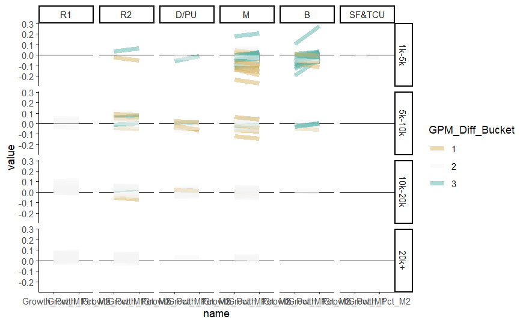

```r
tibble(
  unit_id = rownames(coef(m_public_1)$unit_id) %>% as.numeric(),
  M1_Intcpt = coef(m_public_1)$unit_id[,"(Intercept)"],
  M1_Slope = coef(m_public_1)$unit_id[,"x_year"],
  M2_Slope = coef(m_public_2)$unit_id[,"x_year"],
  Growth_Pct_M1 = M1_Slope / M1_Intcpt,
  Growth_Pct_M2 = M2_Slope / M1_Intcpt,
  GPM_Diff = Growth_Pct_M2 - Growth_Pct_M1,
  GPM_Diff_Bucket = case_when(
    GPM_Diff < -0.01 ~ 1,
    GPM_Diff < 0.01 ~ 2,
    GPM_Diff >= 0.01 ~ 3
  ) %>% factor()
) %>%
  pivot_longer(cols=5:6) %>%
  left_join(
    y = public_fyr_normalized %>% distinct(unit_id, carnegie_category, size_category),
    by = "unit_id"
  ) %>%
  ggplot(aes(x=name, y=value)) +
  geom_hline(yintercept = 0) +
  geom_line(aes(group=unit_id, color=GPM_Diff_Bucket), alpha = 0.5, linewidth=2) +
  scale_color_brewer(type="div") +
  facet_grid(size_category ~ carnegie_category) +
  theme_classic()
ggsave("../Results/m2_slope_shift_public.png")
```

## Model 2 Estimation: Private

```r
m_private_2 <- lmer(formula_2, private_dat3_x5)
summary(m_private_2)
```

```
Linear mixed model fit by REML ['lmerMod']
Formula: first_time_enrollment ~ 1 + x_year + x_rural + sx_bach + sx_hs +      (1 + x_year | unit_id)
   Data: private_dat3_x5

REML criterion at convergence: 44393.5

Scaled residuals:
     Min       1Q   Median       3Q      Max
-14.9714  -0.2647  -0.0152   0.2354  12.9871

Random effects:
 Groups   Name        Variance Std.Dev. Corr
 unit_id  (Intercept) 528185   726.76
          x_year        2543    50.43   0.64
 Residual              10930   104.54
Number of obs: 3310, groups:  unit_id, 662

Fixed effects:
                  Estimate Std. Error t value
(Intercept)        712.343     31.655  22.504
x_year               4.941      2.344   2.108
x_ruralTown/Rural -173.262     62.211  -2.785
sx_bach             91.101     25.723   3.542
sx_hs               21.795     25.057   0.870

Correlation of Fixed Effects:
            (Intr) x_year x_rT/R sx_bch
x_year       0.430
x_rrlTwn/Rr -0.440  0.003
sx_bach     -0.106  0.003  0.230
sx_hs       -0.080  0.018  0.184  0.162
```

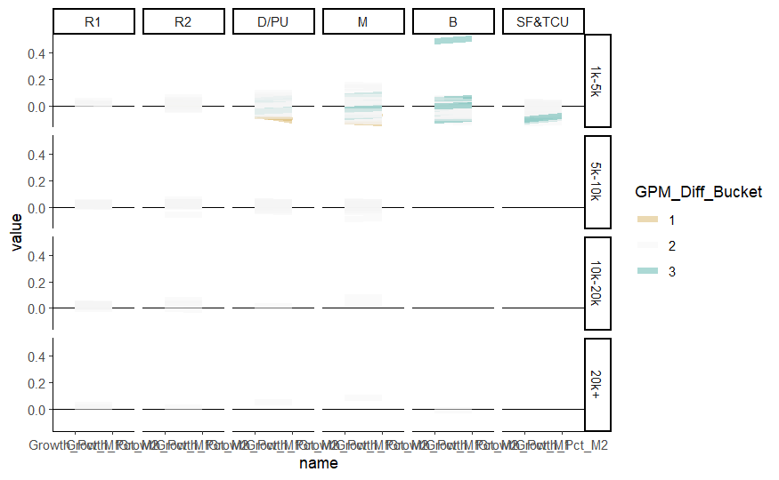

```r
tibble(
  unit_id = rownames(coef(m_private_1)$unit_id) %>% as.numeric(),
  M1_Intcpt = coef(m_private_1)$unit_id[,"(Intercept)"],
  M1_Slope = coef(m_private_1)$unit_id[,"x_year"],
  M2_Slope = coef(m_private_2)$unit_id[,"x_year"],
  Growth_Pct_M1 = M1_Slope / M1_Intcpt,
  Growth_Pct_M2 = M2_Slope / M1_Intcpt,
  GPM_Diff = Growth_Pct_M2 - Growth_Pct_M1,
  GPM_Diff_Bucket = case_when(
    GPM_Diff < -0.01 ~ 1,
    GPM_Diff < 0.01 ~ 2,
    GPM_Diff >= 0.01 ~ 3
  ) %>% factor()
) %>%
  pivot_longer(cols=5:6) %>%
  left_join(
    y = private_fyr_normalized %>% distinct(unit_id, carnegie_category, size_category),
    by = "unit_id"
  ) %>%
  ggplot(aes(x=name, y=value)) +
  geom_hline(yintercept = 0) +
  geom_line(aes(group=unit_id, color=GPM_Diff_Bucket), alpha = 0.5, linewidth=2) +
  scale_color_brewer(type="div") +
  facet_grid(size_category ~ carnegie_category) +
  theme_classic()
ggsave("../Results/m2_slope_shift_private.png")
```

# Model 3: Institutional Actions

```r
formula_3 <- formula(
  first_time_enrollment ~
    1
    + x_year
    + x_rural
    + sx_bach # Percent of adults with bachelors degree in the state where the institution is located, standardized
    + sx_hs # The number of high school graduates that year, logged and standardized
    + sx_race_minority
    + sx_pell
    + sx_apps
    + sx_admit_rate
    + sx_price
    # + (1 + x_year | carnegie)
    + (1 + x_year | unit_id)
)
```

# Model Estimation: Public

```r
m_public_3 <- lmer(formula = formula_3, data = public_dat3_x5)
summary(m_public_3)
```

```
Linear mixed model fit by REML ['lmerMod']
Formula: first_time_enrollment ~ 1 + x_year + x_rural + sx_bach + sx_hs +
    sx_race_minority + sx_pell + sx_apps + sx_admit_rate + sx_price +      (1 + x_year | unit_id)
   Data: public_dat3_x5

REML criterion at convergence: 35240.6

Scaled residuals:
    Min      1Q  Median      3Q     Max
-6.6296 -0.3634 -0.0109  0.3389  5.2196

Random effects:
 Groups   Name        Variance Std.Dev. Corr
 unit_id  (Intercept) 1655816  1286.8
          x_year        11634   107.9   0.69
 Residual               42919   207.2
Number of obs: 2395, groups:  unit_id, 479

Fixed effects:
                  Estimate Std. Error t value
(Intercept)       2396.737     69.458  34.506
x_year              -5.073      6.447  -0.787
x_ruralTown/Rural -650.596    112.037  -5.807
sx_bach           -153.590     52.215  -2.941
sx_hs              219.735     55.989   3.925
sx_race_minority  -129.052     46.489  -2.776
sx_pell           -109.987     31.603  -3.480
sx_apps            767.312     33.351  23.007
sx_admit_rate      156.503     13.765  11.370
sx_price            14.423     16.313   0.884

Correlation of Fixed Effects:
            (Intr) x_year x_rT/R sx_bch sx_hs  sx_rc_ sx_pll sx_pps sx_dm_
x_year       0.426
x_rrlTwn/Rr -0.516 -0.095
sx_bach     -0.039  0.032  0.067
sx_hs       -0.073  0.045  0.123 -0.205
sx_rc_mnrty -0.018 -0.255  0.126 -0.067 -0.234
sx_pell      0.021  0.297 -0.142  0.106 -0.077 -0.341
sx_apps     -0.055 -0.204  0.150  0.011 -0.136 -0.102  0.039
sx_admit_rt -0.002 -0.194  0.064  0.069  0.034 -0.052  0.083  0.340
sx_price     0.027 -0.077 -0.026 -0.079  0.071  0.067  0.027 -0.082 -0.004
```

```r
coef(m_public_3)
```

```
$unit_id
       (Intercept)      x_year x_ruralTown/Rural   sx_bach    sx_hs sx_race_minority   sx_pell  sx_apps sx_admit_rate sx_price
100654   1927.5143   15.406378         -650.5964 -153.5898 219.7347        -129.0516 -109.9869 767.3124      156.5027 14.42284
100663   2032.8865  -69.054964         -650.5964 -153.5898 219.7347        -129.0516 -109.9869 767.3124      156.5027 14.42284
100706   1351.5760  -80.834480         -650.5964 -153.5898 219.7347        -129.0516 -109.9869 767.3124      156.5027 14.42284
100724   1456.9267  -22.853948         -650.5964 -153.5898 219.7347        -129.0516 -109.9869 767.3124      156.5027 14.42284
100751   5269.2611  305.160581         -650.5964 -153.5898 219.7347        -129.0516 -109.9869 767.3124      156.5027 14.42284
100830   1051.2782  -10.727906         -650.5964 -153.5898 219.7347        -129.0516 -109.9869 767.3124      156.5027 14.42284
100858   3763.3854  133.217176         -650.5964 -153.5898 219.7347        -129.0516 -109.9869 767.3124      156.5027 14.42284
101480   1398.6826    7.003704         -650.5964 -153.5898 219.7347        -129.0516 -109.9869 767.3124      156.5027 14.42284
101587   1759.4229   13.995272         -650.5964 -153.5898 219.7347        -129.0516 -109.9869 767.3124      156.5027 14.42284
101709   1458.3960  -34.945572         -650.5964 -153.5898 219.7347        -129.0516 -109.9869 767.3124      156.5027 14.42284
101879   1418.7152  -85.124807         -650.5964 -153.5898 219.7347        -129.0516 -109.9869 767.3124      156.5027 14.42284
102094   1577.7398  -40.194184         -650.5964 -153.5898 219.7347        -129.0516 -109.9869 767.3124      156.5027 14.42284
102368   2312.1581  -32.575906         -650.5964 -153.5898 219.7347        -129.0516 -109.9869 767.3124      156.5027 14.42284
```

[output cut: 91 more lines]

```r
m_private_3 <- lmer(formula = formula_3, data = private_dat3_x5)
summary(m_private_3)
coef(m_private_3)
```

[output not shown]

The model did not converge. Let’s explore what’s going on

```r
cor(private_dat3_x5$sx_apps, private_dat3_x5$sx_admit_rate) # correlation is ~ -0.5 so not collinear

cor(private_dat3_x5[,c(
  "sx_apps"
  ,"sx_admit_rate"
  ,"sx_pell"
  ,"sx_price"
  ,"sx_race_minority"
  )
  ]
)

glmer(formula = formula_3, data = private_dat3_x5, family = "poisson") # this runs
```

From https://www.geeksforgeeks.org/how-to-resolve-r-glmer-warnings-model-fails-to-converge-and-model-is-nearly-unidentifiable/?ref=asr4

> Model Fails to Converge: This warning suggests that the algorithm used to fit the GLMM did not successfully find a solution that meets convergence criteria. Convergence failure can occure due to various reasons, including: * Poor starting values for the optimization algorithm * Non-linear relationships between predictors and the response variable * High collinearity among predictors * Overdispersion or underdispersion in the data * Sparse data or small sample sizes

I think we can rule out collinearity despite the natural relationship between total number of applications and admission rate because even then the correlation between them is not close to 1.

I think overdispersion is much more likely given that we were already thinking that might be a problem.

```r
glm_public_1 <- glmer(formula = formula_1, data = public_dat3_x5, family = "poisson")
glm_public_2 <- glmer(formula = formula_2, data = public_dat3_x5, family = "poisson")
glm_public_3 <- glmer(formula = formula_3, data = public_dat3_x5, family = "poisson")

glm_private_1 <- glmer(formula = formula_1, data = private_dat3_x5, family = "poisson")
glm_private_2 <- glmer(formula = formula_2, data = private_dat3_x5, family = "poisson")
glm_private_3 <- glmer(formula = formula_3, data = private_dat3_x5, family = "poisson")
```

```r
glmer.nb(formula_3, data=public_dat3_x5)
```

```r
map(
  .x = list(
    glm_public_1,
    glm_public_2,
    glm_public_3,
    glm_private_1,
    glm_private_2,
    glm_private_3
  ),
  .f = summary
)
```

```
[[1]]
Generalized linear mixed model fit by maximum likelihood (Laplace Approximation) ['glmerMod']
 Family: poisson  ( log )
Formula: first_time_enrollment ~ 1 + x_year + (1 + x_year | unit_id)
   Data: public_dat3_x5

     AIC      BIC   logLik deviance df.resid
 50574.5  50603.4 -25282.3  50564.5     2390

Scaled residuals:
     Min       1Q   Median       3Q      Max
-15.9003  -1.7218   0.0779   1.6780  16.7123

Random effects:
 Groups  Name        Variance Std.Dev. Corr
 unit_id (Intercept) 0.900456 0.94892
         x_year      0.003139 0.05603  0.23
Number of obs: 2395, groups:  unit_id, 479

Fixed effects:
              Estimate Std. Error z value Pr(>|z|)
(Intercept)  7.2573781  0.0433737 167.322   <2e-16 ***
x_year      -0.0003065  0.0026059  -0.118    0.906
---
Signif. codes:  0 ‘***’ 0.001 ‘**’ 0.01 ‘*’ 0.05 ‘.’ 0.1 ‘ ’ 1

Correlation of Fixed Effects:
       (Intr)
x_year 0.222

[[2]]
Generalized linear mixed model fit by maximum likelihood (Laplace Approximation) ['glmerMod']
 Family: poisson  ( log )
Formula: first_time_enrollment ~ 1 + x_year + x_rural + sx_bach + sx_hs +      (1 + x_year | unit_id)
   Data: public_dat3_x5

     AIC      BIC   logLik deviance df.resid
 50441.7  50487.9 -25212.8  50425.7     2387

Scaled residuals:
```

[output cut: 170 more lines]

```
sx_price          -0.0020883  0.0026594  -0.785  0.43231
---
Signif. codes:  0 ‘***’ 0.001 ‘**’ 0.01 ‘*’ 0.05 ‘.’ 0.1 ‘ ’ 1

Correlation of Fixed Effects:
            (Intr) x_year x_rT/R sx_bch sx_hs  sx_rc_ sx_pll sx_pps sx_dm_
x_year       0.024
x_rrlTwn/Rr -0.485 -0.024
sx_bach     -0.115  0.039  0.208
sx_hs       -0.086  0.034  0.169  0.155
sx_rc_mnrty  0.005 -0.158  0.067 -0.078 -0.069
sx_pell     -0.015  0.149 -0.027  0.062  0.004 -0.094
sx_apps     -0.013 -0.134  0.064 -0.101 -0.070 -0.013 -0.049
sx_admit_rt  0.005 -0.110  0.030 -0.034 -0.040 -0.018  0.016  0.460
sx_price    -0.006 -0.041  0.028 -0.036 -0.021  0.052  0.036 -0.023  0.028
```

```r
anova(glm_private_1, glm_private_2, glm_private_3)
```

```
Data: private_dat3_x5
Models:
glm_private_1: first_time_enrollment ~ 1 + x_year + (1 + x_year | unit_id)
glm_private_2: first_time_enrollment ~ 1 + x_year + x_rural + sx_bach + sx_hs + (1 + x_year | unit_id)
glm_private_3: first_time_enrollment ~ 1 + x_year + x_rural + sx_bach + sx_hs + sx_race_minority + sx_pell + sx_apps + sx_admit_rate + sx_price + (1 + x_year | unit_id)
              npar   AIC   BIC logLik deviance    Chisq Df Pr(>Chisq)
glm_private_1    5 50151 50181 -25070    50141
glm_private_2    8 50089 50138 -25037    50073   67.209  3  1.689e-14 ***
glm_private_3   13 46346 46425 -23160    46320 3753.449  5  < 2.2e-16 ***
---
Signif. codes:  0 ‘***’ 0.001 ‘**’ 0.01 ‘*’ 0.05 ‘.’ 0.1 ‘ ’ 1
```

Let’s see if number of iterations does something for the non-convergence

```r
allFit(m_private_3)
```

```
bobyqa : [OK]
Nelder_Mead : [OK]
nlminbwrap : [OK]
nloptwrap.NLOPT_LN_NELDERMEAD :
```

```
[OK]
nloptwrap.NLOPT_LN_BOBYQA :
```

```
[OK]
original model:
first_time_enrollment ~ 1 + x_year + x_rural + sx_bach + sx_hs + sx_race_mino...
data:  private_dat3_x5
optimizers (5): bobyqa, Nelder_Mead, nlminbwrap, nloptwrap.NLOPT_LN_NELDERMEAD, nloptwrap.NLO...
differences in negative log-likelihoods:
max= 1.76e-05 ; std dev= 7.68e-06
```

```r
allFit(m_private_3)
```

[output not shown]

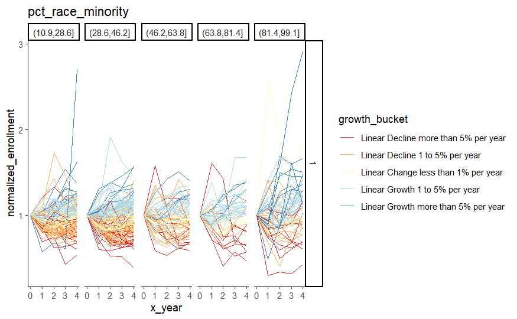

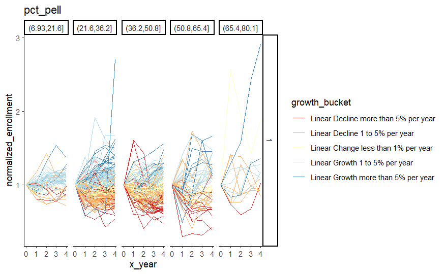

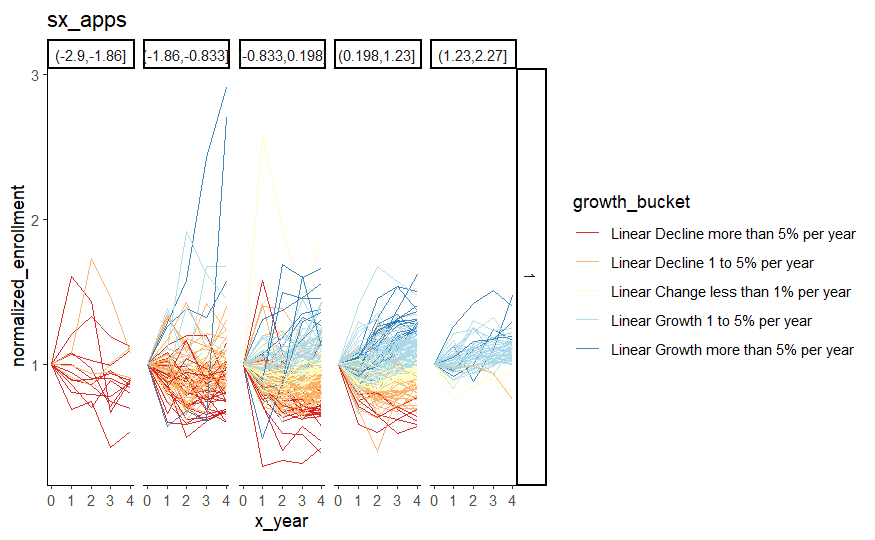

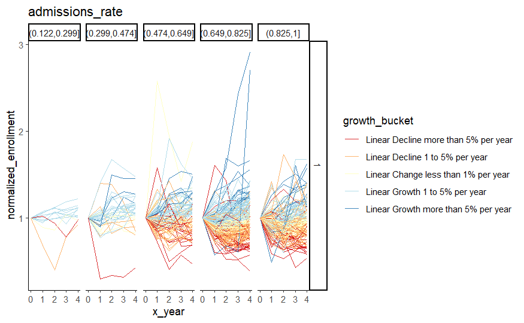

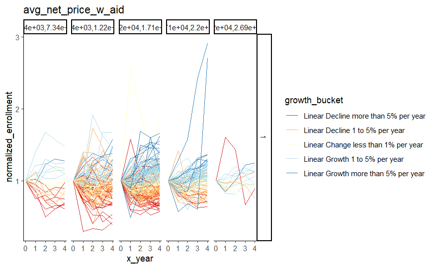

```r
map(
  .x = list(
    "pct_race_minority",
    "pct_pell",
    # "applicants",
    "sx_apps",
    "admissions_rate",
    "avg_net_price_w_aid"
  ),
  .f = function(x) {
    baseline_tertiles <- filter(public_dat3_x5, year==2019)
    baseline_tertiles$xvar_cut <- cut(baseline_tertiles[[x]], 5)
    baseline_tertiles <- select(baseline_tertiles, unit_id, xvar_cut)

    public_fyr_normalized %>%
      left_join(
        y = baseline_tertiles,
        by = "unit_id"
      ) %>%
      ggplot(aes(x=x_year, y=normalized_enrollment)) +
      geom_line(mapping=aes(group=unit_id, color=growth_bucket), alpha = 0.9) +
      scale_color_brewer(type="div", palette = "RdYlBu") +
      facet_grid(1 ~ xvar_cut) +
      theme_classic() +
      ggplot2::ggtitle(x)
  }
)
```

# Prototypes?

| unit_id | Rank1 | Rank2 | Rank3 | Rank4 | Rank5 | Tot_Rank | N_year | institution_name | year | pct_pell | overall_enrollment | pct_race_minority | avg_net_price_w_aid | applicants | admissions_rate | stabbr | locale_rural | hs_grad_state | pct_bachelors_2018_state | carnegie | sector | first_time_enrollment | year_0 | log_fyr | log_hs | log_apps | log_price | sy_fyr | x_year | … |
| --- | --- | --- | --- | --- | --- | --- | --- | --- | --- | --- | --- | --- | --- | --- | --- | --- | --- | --- | --- | --- | --- | --- | --- | --- | --- | --- | --- | --- | --- | --- |
| 197027 | 394 | 479 | 460 | 387 | 434 | 2154 | 5 | United States Merchant Marine Academy | 2019 | 7 | 1007 | 21 | 4617 | 1693 | 0.2486710 | NY | City/Suburb | 212104 | 37.2 | Baccalaureate | public | 255 | 0 | 5.541264 | 12.264832 | 7.434257 | 8.437500 | -1.6565025 | 0 | … |
| 160630 | 247 | 463 | 445 | 447 | 454 | 2056 | 5 | Southern University at New Orleans | 2019 | 60 | 1894 | 98 | 6761 | 1016 | 0.6033465 | LA | City/Suburb | 52809 | 24.3 | M | public | 221 | 0 | 5.398163 | 10.874437 | 6.923629 | 8.818926 | -1.7969974 | 0 | … |
| 190637 | 129 | 474 | 478 | 458 | 465 | 2004 | 5 | CUNY Lehman College | 2019 | 56 | 13002 | 95 | 2709 | 19761 | 0.3777643 | NY | City/Suburb | 212104 | 37.2 | M | public | 942 | 0 | 6.848005 | 12.264832 | 9.891466 | 7.904335 | -0.3735567 | 0 | … |
| 237215 | 478 | 399 | 161 | 477 | 473 | 1988 | 5 | Bluefield State University | 2019 | 55 | 1241 | 16 | 8445 | 470 | 0.9446809 | WV | Town/Rural | 19036 | 21.3 | Baccalaureate | public | 200 | 0 | 5.298317 | 9.854087 | 6.152733 | 9.041330 | -1.8950246 | 0 | … |
| 110592 | 87 | 476 | 479 | 453 | 467 | 1962 | 5 | California State University-Los Angeles | 2019 | 68 | 22797 | 95 | 3255 | 33641 | 0.4781071 | CA | City/Suburb | 478819 | 34.2 | M | public | 3287 | 0 | 8.097731 | 13.079078 | 10.423501 | 8.087948 | 0.8534109 | 0 | … |

| unit_id | N_year | institution_name | year | pct_pell | overall_enrollment | pct_race_minority | avg_net_price_w_aid | applicants | admissions_rate | stabbr | locale_rural | hs_grad_state | pct_bachelors_2018_state | carnegie | sector | first_time_enrollment | year_0 | log_fyr | log_hs | log_apps | log_price | sy_fyr | x_year | sx_hs | sx_bach | x_rural | sx_pell | sx_race_minority | sx_price | … |
| --- | --- | --- | --- | --- | --- | --- | --- | --- | --- | --- | --- | --- | --- | --- | --- | --- | --- | --- | --- | --- | --- | --- | --- | --- | --- | --- | --- | --- | --- | --- |
| 174075 | 5 | University of Minnesota-Crookston | 2019 | 23 | 2768 | 37 | 11483 | 1182 | 0.6844332 | MN | Town/Rural | 65499 | 36.7 | Baccalaureate | public | 214 | 0 | 5.365976 | 11.089790 | 7.074963 | 9.348623 | -1.82859801 | 0 | -0.2694711 | 0.84517540 | Town/Rural | -0.9301020 | -0.38271616 | -0.5069164 | … |
| 200059 | 5 | Dickinson State University | 2019 | 23 | 1321 | 22 | 10817 | 376 | 0.9973404 | ND | Town/Rural | 7006 | 29.7 | Baccalaureate | public | 202 | 0 | 5.308268 | 8.854522 | 5.929589 | 9.288874 | -1.88525545 | 0 | -2.5050656 | -0.46373882 | Town/Rural | -0.9301020 | -1.00253924 | -0.6780189 | … |
| 218654 | 5 | University of South Carolina Beaufort | 2019 | 41 | 2112 | 39 | 16807 | 2167 | 0.6275958 | SC | Town/Rural | 53953 | 28.3 | Baccalaureate | public | 449 | 0 | 6.107023 | 10.895869 | 7.681099 | 9.729551 | -1.10104570 | 0 | -0.4634210 | -0.72552167 | Town/Rural | 0.4349317 | -0.30007308 | 0.5839468 | … |
| 157401 | 5 | Murray State University | 2019 | 31 | 8139 | 19 | 11512 | 8327 | 0.8239462 | KY | Town/Rural | 51210 | 24.8 | M | public | 1421 | 0 | 7.259116 | 10.843690 | 9.027259 | 9.351145 | 0.03006775 | 0 | -0.5156071 | -1.37997878 | Town/Rural | -0.3234203 | -1.12650386 | -0.4996933 | … |
| 176965 | 5 | University of Central Missouri | 2019 | 31 | 8904 | 23 | 13098 | 5699 | 0.6502895 | MO | Town/Rural | 68482 | 29.5 | M | public | 1249 | 0 | 7.130099 | 11.134326 | 8.648046 | 9.480215 | -0.09660044 | 0 | -0.2249285 | -0.50113637 | Town/Rural | -0.3234203 | -0.96121770 | -0.1300767 | … |
| 240374 | 5 | University of Wisconsin-Parkside | 2019 | 40 | 3906 | 37 | 10154 | 2256 | 0.6582447 | WI | Town/Rural | 68191 | 30.0 | M | public | 657 | 0 | 6.487684 | 11.130068 | 7.721349 | 9.225623 | -0.72731647 | 0 | -0.2291875 | -0.40764250 | Town/Rural | 0.3590965 | -0.38271616 | -0.8591515 | … |
| 182290 | 5 | University of Nevada-Reno | 2019 | 26 | 17297 | 45 | 16253 | 9064 | 0.8821712 | NV | City/Suburb | 32173 | 24.9 | R1 | public | 3547 | 0 | 8.173857 | 10.378883 | 9.112066 | 9.696033 | 0.92815151 | 0 | -0.9804822 | -1.36128000 | City/Suburb | -0.7025964 | -0.05214385 | 0.4879614 | … |
| 199218 | 5 | University of North Carolina Wilmington | 2019 | 27 | 14785 | 22 | 17981 | 13287 | 0.6545496 | NC | City/Suburb | 114284 | 31.9 | R2 | public | 2342 | 0 | 7.758761 | 11.646442 | 9.494541 | 9.797071 | 0.52061357 | 0 | 0.2872619 | -0.05236578 | City/Suburb | -0.6267612 | -1.00253924 | 0.7773044 | … |
| 221759 | 5 | The University of Tennessee-Knoxville | 2019 | 25 | 23290 | 22 | 21024 | 21764 | 0.7884580 | TN | City/Suburb | 72802 | 27.5 | R1 | public | 5254 | 0 | 8.566745 | 11.195499 | 9.988013 | 9.953420 | 1.31388448 | 0 | -0.1637471 | -0.87511186 | City/Suburb | -0.7784316 | -1.00253924 | 1.2250412 | … |

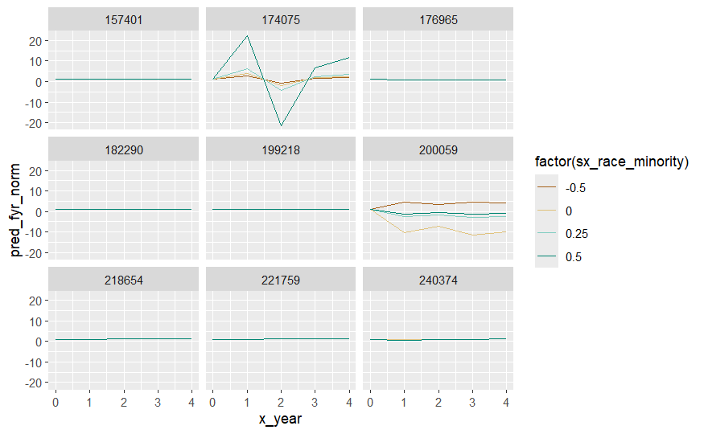